# chapter6

Yuwen Pang

23/11/2021

# Chapter 6 Analysis of longitudinal data

```r
options(knitr.duplicate.label = "allow")
```

```r
date()
```

```
## [1] "Thu Dec 09 09:54:44 2021"
```

## 1 Load the longitudinal bprsl and ratsl datasets

```r
library(dplyr)
library(tidyr)
library(ggplot2)

# Set the working directory
setwd("Z:/Course/Opendata science/IODS-project")

# read the longitudinal and original datasets
rats <- read.table("https://raw.githubusercontent.com/KimmoVehkalahti/MABS/master/Examples/data/rats.txt", sep="", header=TRUE)
bprs <- read.csv("https://raw.githubusercontent.com/KimmoVehkalahti/MABS/master/Examples/data/BPRS.txt", sep="", header=TRUE)

bprsl <- read.csv('data/bprsl.csv', sep = ",", header = TRUE, stringsAsFactors = TRUE)
ratsl <- read.csv('data/ratsl.csv', sep = ",", header = TRUE, stringsAsFactors = TRUE)

bprsl <- bprsl[,-1]
ratsl <- ratsl[,-1]

# Dimension of two form of data
dim(rats) #16*13
```

```
## [1] 16 13
```

```r
dim(ratsl) #176*5
```

```
## [1] 176   5
```

```r
dim(bprs) #40*11
```

```
## [1] 40 11
```

```r
dim(bprsl) #360*5
```

```
## [1] 360   5
```

## 2.1 Summary Measure Analysis for ratsl data, the Chapter8 analysis

## Graphical Displays and Summary Measure Approach

Interpretations: -1 in ratsl data, the weight ~ Time + Group + ID

-2 Base on graphs, we could see: (1) wight increased with time in all groups

(2)the weight trends clearly separated in three groups:in which group1 had quite low values, and group 2 and 3 shard similar wight regions, from 400-550.

3. Additionally, one ID in Group2 exceptional high weight, ranged from 550 to 640.

```r
names(ratsl)
```

```
## [1] "ID"     "Group"  "time"   "weight" "Time"
```

```r
str(ratsl)
```

```
## 'data.frame':    176 obs. of  5 variables:
##  $ ID    : int  1 2 3 4 5 6 7 8 9 10 ...
##  $ Group : int  1 1 1 1 1 1 1 1 2 2 ...
##  $ time  : Factor w/ 11 levels "WD1","WD15","WD22",..: 1 1 1 1 1 1 1 1 1 1 ...
##  $ weight: int  240 225 245 260 255 260 275 245 410 405 ...
##  $ Time  : int  1 1 1 1 1 1 1 1 1 1 ...
```

```r
# Convert Group and ID as factor varibles
ratsl$ID <- as.factor(ratsl$ID)
ratsl$Group <- as.factor(ratsl$Group)
ratsl$Time <- as.factor(ratsl$Time)
str(ratsl)
```

```
## 'data.frame':    176 obs. of  5 variables:
##  $ ID    : Factor w/ 16 levels "1","2","3","4",..: 1 2 3 4 5 6 7 8 9 10 ...
##  $ Group : Factor w/ 3 levels "1","2","3": 1 1 1 1 1 1 1 1 2 2 ...
##  $ time  : Factor w/ 11 levels "WD1","WD15","WD22",..: 1 1 1 1 1 1 1 1 1 1 ...
##  $ weight: int  240 225 245 260 255 260 275 245 410 405 ...
##  $ Time  : Factor w/ 11 levels "1","8","15","22",..: 1 1 1 1 1 1 1 1 1 1 ...
```

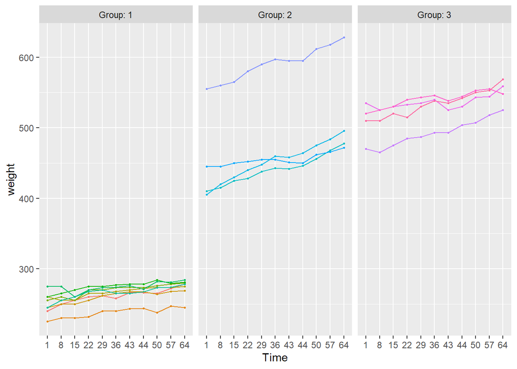

```r
# Draw the plot of ratsl
# Plot1
ggplot(ratsl, aes(x = Time, y = weight, color = ID)) +
  geom_point(size=0.5) +
  geom_line(aes(group = ID)) +
  facet_grid(. ~ Group, labeller = label_both) +
  theme(legend.position = "none") +
  scale_y_continuous(limits = c(min(ratsl$weight), max(ratsl$weight)))
```

## 2.2 Summary Measure Analysis- Line plots

-2 In group1 and 3, there was one ID showed a significant low standardized weight trend line, while in group2, one curve/line posed in high value regions.

-3 here, i could more clearly found that the weight development with time varied in three groups, in which upward and downward trend both presented.

-4 the plot2 clearly shown the values gaps among three groups and illustrated their temporal trends, in which group 2 and 3 visible increased while group relatively stable.

```r
# Based on previous plots, I firstly group ratsl by Time
# Standardise the variable weight by Time
ratsl.gb <- ratsl %>%
  group_by(Group, Time) %>%
  mutate(stdweight = (weight - mean(weight))/sd(weight)) %>%
  ungroup()
dim(ratsl) #176*5
```

```
## [1] 176   5
```

```r
dim(ratsl.gb) #176*6
```

```
## [1] 176   6
```

```r
names(ratsl)
```

```
## [1] "ID"     "Group"  "time"   "weight" "Time"
```

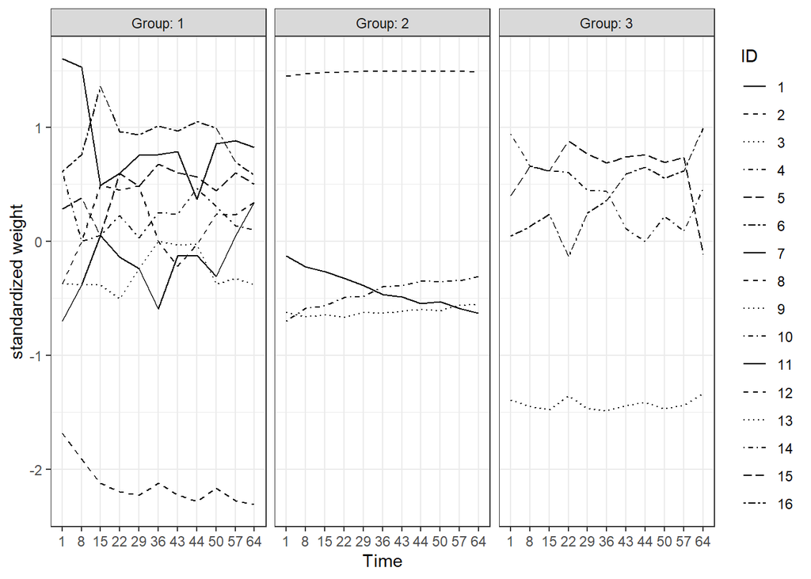

```r
# Plot again with the standardised weight
ggplot(ratsl.gb, aes(x = Time, y = stdweight, linetype = ID)) +
  scale_linetype_manual(values = rep(1:10, times=4)) +
  geom_line(aes(group = ID)) +
  facet_grid(. ~ Group, labeller = label_both) +
  scale_y_continuous(name = "standardized weight") +
  theme_bw()
```

```r
# Number/levels of Times
n <- ratsl$Time %>% unique() %>% length()

# Summary rats with mean and standard error of weight by Group and Time
ratss.gb <- ratsl %>%
  group_by(Group, Time) %>%
  summarise(mean = mean(weight), se = sd(weight)/sqrt(n)) %>%
  ungroup()
ratss.gb %>% summary()
```

```
##  Group       Time         mean             se
##  1:11   1      : 3   Min.   :250.6   Min.   : 3.074
##  2:11   8      : 3   1st Qu.:269.5   1st Qu.: 4.101
##  3:11   15     : 3   Median :486.5   Median : 7.358
##         22     : 3   Mean   :424.7   Mean   :10.703
##         29     : 3   3rd Qu.:518.2   3rd Qu.:21.047
##         36     : 3   Max.   :550.2   Max.   :22.390
##         (Other):15
```

```r
dim(ratss.gb) #33*4
```

```
## [1] 33  4
```

```r
# Glimpse the grouped ratss data
glimpse(ratss.gb)
```

```
## Rows: 33
## Columns: 4
## $ Group <fct> 1, 1, 1, 1, 1, 1, 1, 1, 1, 1, 1, 2, 2, 2, 2, 2, 2, 2, 2, 2, 2, 2~
## $ Time  <fct> 1, 8, 15, 22, 29, 36, 43, 44, 50, 57, 64, 1, 8, 15, 22, 29, 36, ~
## $ mean  <dbl> 250.625, 255.000, 254.375, 261.875, 264.625, 265.000, 267.375, 2~
## $ se    <dbl> 4.589478, 3.947710, 3.460116, 4.100800, 3.333956, 3.552939, 3.30~
```

```r
# Plot the mean profiles
names(ratss.gb) #"Group" "Time"  "mean"  "se"
```

```
## [1] "Group" "Time"  "mean"  "se"
```

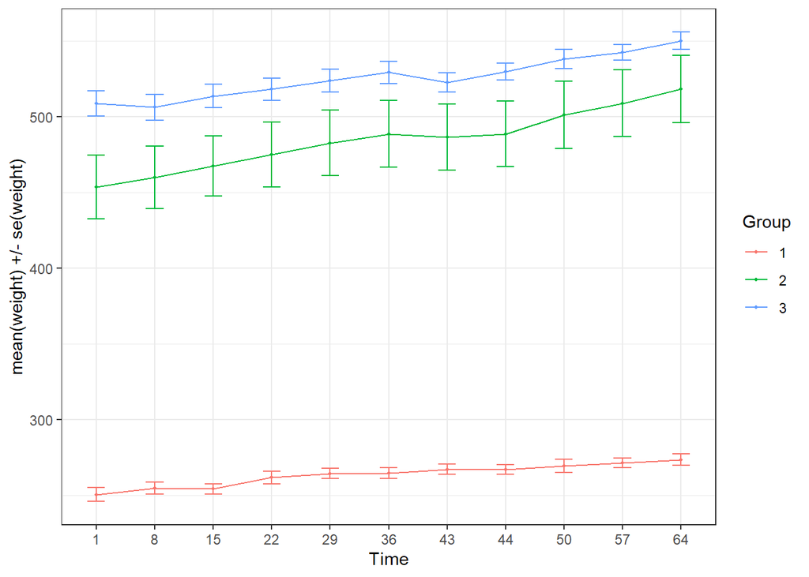

```r
ggplot(ratss.gb, aes(x = Time, y = mean, color = Group)) +
  geom_point(size=0.8) +
  geom_line(aes(group = Group)) +
  geom_errorbar(aes(ymin = mean - se, ymax = mean + se), width=0.3) +
  scale_y_continuous(name = "mean(weight) +/- se(weight)") +
  theme_bw()
```

## 2.3 Summary Measure Analysis- box plots

### found out the outliers

```r
# Create a summary data by GROUP and ID
ratss.gb2 <- ratsl %>%
  group_by(Group, ID) %>%
  summarise(mean=mean(weight)) %>%
  ungroup()
dim(ratss.gb2) #16*3
```

```
## [1] 16  3
```

```r
# Glimpse the data
glimpse(ratss.gb2)
```

```
## Rows: 16
## Columns: 3
## $ Group <fct> 1, 1, 1, 1, 1, 1, 1, 1, 2, 2, 2, 2, 3, 3, 3, 3
## $ ID    <fct> 1, 2, 3, 4, 5, 6, 7, 8, 9, 10, 11, 12, 13, 14, 15, 16
## $ mean  <dbl> 261.0909, 237.6364, 260.1818, 266.5455, 269.4545, 274.7273, 274.~
```

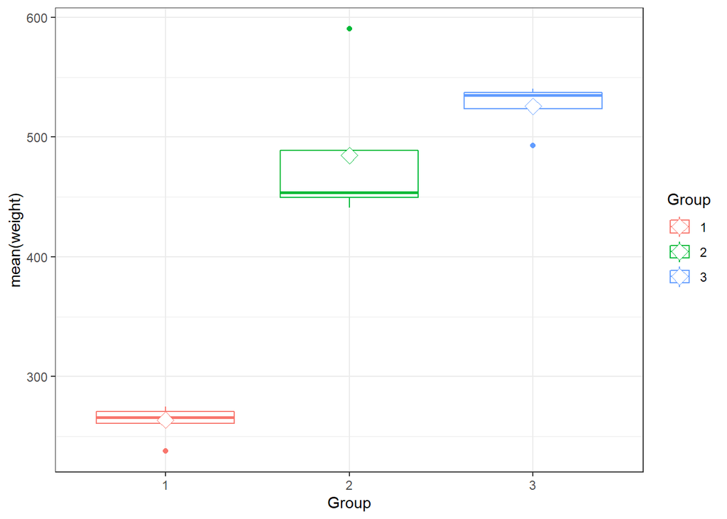

```r
# Draw a boxplot of the mean versus group
ggplot(ratss.gb2, aes(x = Group, y = mean, color = Group)) +
  geom_boxplot() +
  stat_summary(fun = "mean", geom = "point", shape=23, size=4, fill = "white") +
  scale_y_continuous(name = "mean(weight)") +
  theme_bw()
```

```r
# Remove the outliers
ratss.gb3 <- ratss.gb2 %>%
  filter((Group==1 & mean > 250)|(Group==2 & mean < 550)| (Group==3 & mean > 500))
dim(ratss.gb3) #15*3
```

```
## [1] 13  3
```

```r
dim(ratss.gb2) #16*3
```

```
## [1] 16  3
```

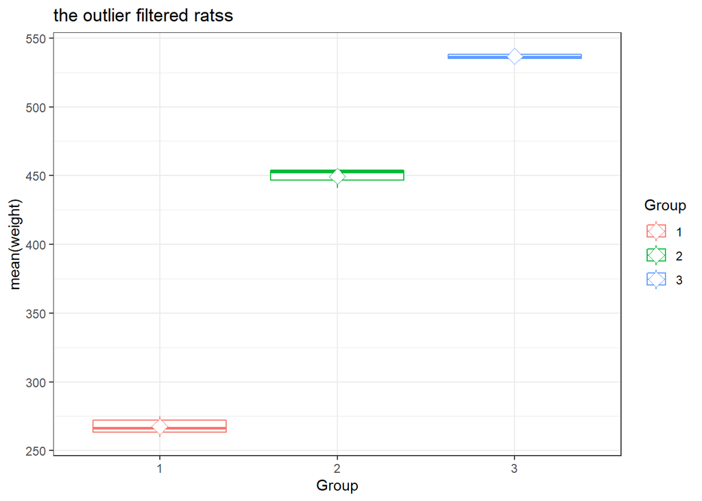

```r
# Draw the new boxplot of the mean versus group
ggplot(ratss.gb3, aes(x = Group, y = mean, color = Group)) +
  geom_boxplot() +
  stat_summary(fun = "mean", geom = "point", shape=23, size=4, fill = "white") +
  scale_y_continuous(name = "mean(weight)") +
  ggtitle("the outlier filtered ratss") +
  theme_bw()
```

-1 the linear model,fit1, reported that the group variable is significant

-2 the fit2 revealed that time and group both significantly impact weight

```r
# Fit the linear model with the mean as the response
fit1 <- lm(mean ~ Group, data = ratss.gb3)

# Compute the analysis of variance table for the fitted model with anova()
anova(fit1)
```

```
## Analysis of Variance Table
##
## Response: mean
##           Df Sum Sq Mean Sq F value    Pr(>F)
## Group      2 175958   87979  2577.4 2.721e-14 ***
## Residuals 10    341      34
## ---
## Signif. codes:  0 '***' 0.001 '**' 0.01 '*' 0.05 '.' 0.1 ' ' 1
```

```r
# Fit the linear model with the mean as the response
names(ratss.gb)
```

```
## [1] "Group" "Time"  "mean"  "se"
```

```r
# "Group" "Time"  "ID"    "mean"  "se"

fit2 <- lm(mean ~ Group + Time, data = ratss.gb)

# Compute the analysis of variance table for the fitted model with anova()
anova(fit2)
```

```
## Analysis of Variance Table
##
## Response: mean
##           Df Sum Sq Mean Sq  F value    Pr(>F)
## Group      2 437104  218552 4908.646 < 2.2e-16 ***
## Time      10   5625     563   12.634  1.34e-06 ***
## Residuals 20    890      45
## ---
## Signif. codes:  0 '***' 0.001 '**' 0.01 '*' 0.05 '.' 0.1 ' ' 1
```

## 3 Linear Mixed Effects Models for bprsl data, the Chapter9 analysis

-1 bprs ~ treatment + subject + week, the potential formulation

```r
library(dplyr)
library(tidyr)
library(ggplot2)

# Load bprs and bprsl
bprs <- read.csv("https://raw.githubusercontent.com/KimmoVehkalahti/MABS/master/Examples/data/BPRS.txt", sep="", header=TRUE)
bprsl <- read.csv('data/bprsl.csv', sep = ",", header = TRUE, stringsAsFactors = TRUE)
bprsl <- bprsl[,-1]

# the dimension of two form of data
dim(bprs) #40*11
```

```
## [1] 40 11
```

```r
dim(bprsl) #360*6
```

```
## [1] 360   5
```

```r
names(bprsl)
```

```
## [1] "treatment" "subject"   "weeks"     "bprs"      "week"
```

```r
str(bprsl)
```

```
## 'data.frame':    360 obs. of  5 variables:
##  $ treatment: int  1 1 1 1 1 1 1 1 1 1 ...
##  $ subject  : int  1 2 3 4 5 6 7 8 9 10 ...
##  $ weeks    : Factor w/ 9 levels "week0","week1",..: 1 1 1 1 1 1 1 1 1 1 ...
##  $ bprs     : int  42 58 54 55 72 48 71 30 41 57 ...
##  $ week     : int  0 0 0 0 0 0 0 0 0 0 ...
```

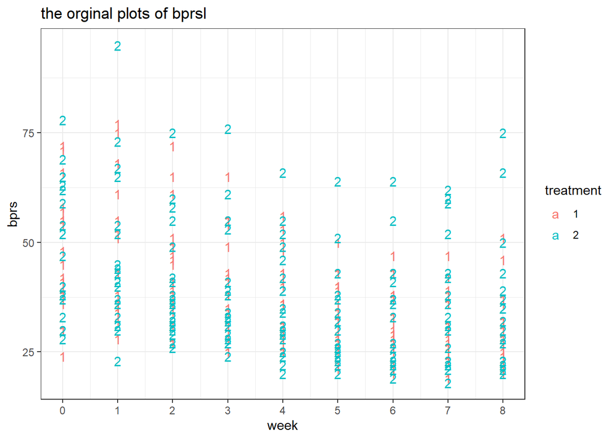

```r
# Convert the categorical variables
bprsl$treatment <- as.factor(bprsl$treatment)
bprsl$subject <- as.factor(bprsl$subject)

# Draw the plot of new long data form
ggplot(bprsl, aes(x = week, y = bprs, group = subject)) +
  geom_text(aes(label = treatment, color = treatment)) +
  # facet_grid(. ~ treatment, labeller = label_both) +
  scale_x_continuous(name = "week", breaks = seq(0, 8, 1)) +
  scale_y_continuous(name = "bprs", limits = c(min(bprsl$bprs), max(bprsl$bprs))) +
  ggtitle("the orginal plots of bprsl") +
  theme_bw()
```

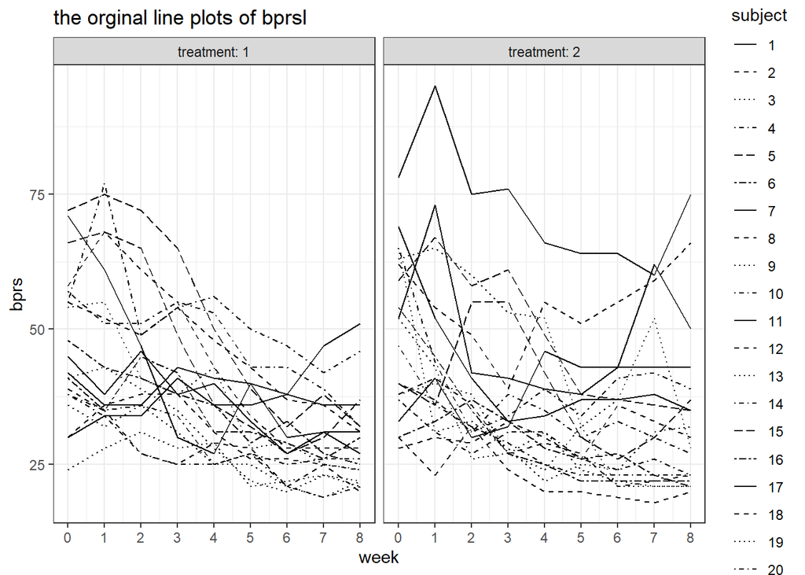

```r
ggplot(bprsl, aes(x = week, y = bprs, linetype = subject)) +
  geom_line() +
  scale_linetype_manual(values = rep(1:10, times=4)) +
  facet_grid(. ~ treatment, labeller = label_both) +
  scale_x_continuous(name = "week", breaks = seq(0, 8, 1)) +
  scale_y_continuous(name = "bprs", limits = c(min(bprsl$bprs), max(bprsl$bprs))) +
  ggtitle("the orginal line plots of bprsl") +
  theme_bw()
```

## 3.2 Exploring bprsl

-1 grouped bprs by subjects, and saw how each treatment varied with week/time

```r
# Number of subject
n <- bprsl$subject %>% unique() %>% length()

# Summary data with mean and standard error of bprs by treatment and week
bprss <- bprsl %>%
  group_by(treatment, week) %>%
  summarise( mean = mean(bprs), se = sd(bprs)/sqrt(n) ) %>%
  ungroup()
```

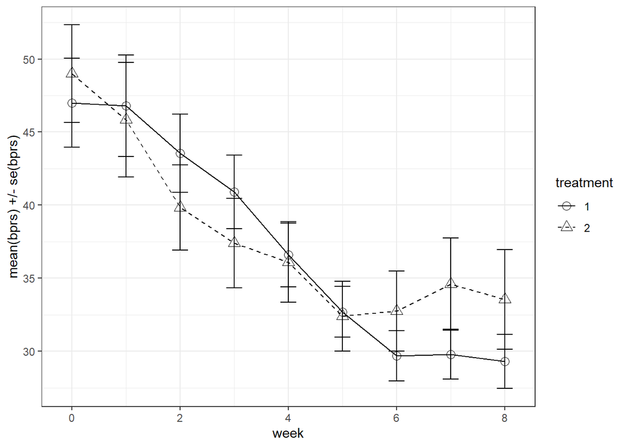

```r
# Plot the mean profiles of subjects
ggplot(bprss, aes(x = week, y = mean, linetype = treatment, shape = treatment)) +
  geom_line(aes(group = treatment)) +
  scale_linetype_manual(values = c(1,2)) +
  geom_point(size=3) +
  scale_shape_manual(values = c(1,2)) +
  geom_errorbar(aes(ymin = mean - se, ymax = mean + se, linetype="1"), width=0.3) +
  scale_y_continuous(name = "mean(bprs) +/- se(bprs)") +
  theme_bw()
```

## 3.3 fit and compare models

-1 the independent variable (or random effect) was ‘subject’, and it influenced by week

-2 built two linear mixed model: fit1 and fit2

```r
# access library lme4
library(lme4)
# Create a random intercept model
bprsl_ref <- lmer(bprs ~ week + treatment  + (1 | subject), data = bprsl, REML = FALSE)

# Print the summary of the model
summary(bprsl_ref)
```

```
## Linear mixed model fit by maximum likelihood  ['lmerMod']
## Formula: bprs ~ week + treatment + (1 | subject)
##    Data: bprsl
##
##      AIC      BIC   logLik deviance df.resid
##   2748.7   2768.1  -1369.4   2738.7      355
##
## Scaled residuals:
##     Min      1Q  Median      3Q     Max
## -3.0481 -0.6749 -0.1361  0.4813  3.4855
##
## Random effects:
##  Groups   Name        Variance Std.Dev.
##  subject  (Intercept)  47.41    6.885
##  Residual             104.21   10.208
## Number of obs: 360, groups:  subject, 20
##
## Fixed effects:
##             Estimate Std. Error t value
## (Intercept)  46.4539     1.9090  24.334
## week         -2.2704     0.2084 -10.896
## treatment2    0.5722     1.0761   0.532
##
## Correlation of Fixed Effects:
##            (Intr) week
## week       -0.437
## treatment2 -0.282  0.000
```

```r
# create a random intercept and random slope model
bprsl_ref1 <- lmer(bprs ~ week + treatment + (week | subject), data = bprsl, REML = FALSE)

# print a summary of the model
summary(bprsl_ref1)
```

```
## Linear mixed model fit by maximum likelihood  ['lmerMod']
## Formula: bprs ~ week + treatment + (week | subject)
##    Data: bprsl
##
##      AIC      BIC   logLik deviance df.resid
##   2745.4   2772.6  -1365.7   2731.4      353
##
## Scaled residuals:
##     Min      1Q  Median      3Q     Max
## -2.8919 -0.6194 -0.0691  0.5531  3.7976
##
## Random effects:
##  Groups   Name        Variance Std.Dev. Corr
##  subject  (Intercept) 64.8222  8.0512
##           week         0.9609  0.9802   -0.51
##  Residual             97.4305  9.8707
## Number of obs: 360, groups:  subject, 20
##
## Fixed effects:
##             Estimate Std. Error t value
## (Intercept)  46.4539     2.1052  22.066
## week         -2.2704     0.2977  -7.626
## treatment2    0.5722     1.0405   0.550
##
## Correlation of Fixed Effects:
##            (Intr) week
## week       -0.582
## treatment2 -0.247  0.000
```

```r
# perform an ANOVA test on the two models
anova(bprsl_ref1, bprsl_ref)
```

```
## Data: bprsl
## Models:
## bprsl_ref: bprs ~ week + treatment + (1 | subject)
## bprsl_ref1: bprs ~ week + treatment + (week | subject)
##            npar    AIC    BIC  logLik deviance  Chisq Df Pr(>Chisq)
## bprsl_ref     5 2748.7 2768.1 -1369.4   2738.7
## bprsl_ref1    7 2745.4 2772.6 -1365.7   2731.4 7.2721  2    0.02636 *
## ---
## Signif. codes:  0 '***' 0.001 '**' 0.01 '*' 0.05 '.' 0.1 ' ' 1
```

## 3.4 plot the fitted model

-1 based on the t-test, anova, the (week|subject) model was be accepted

-2 calculated the fitted values and draw the predicted plot

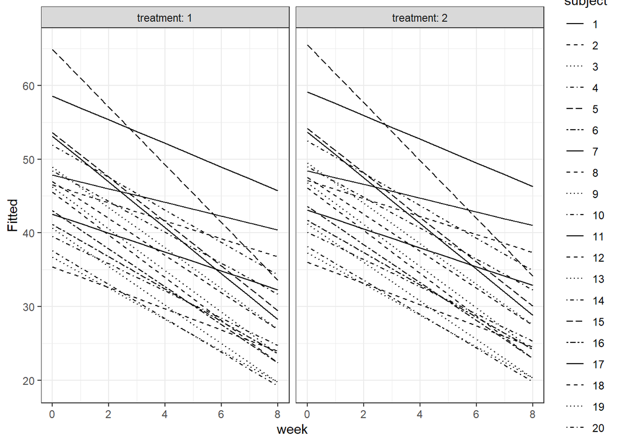

```r
# Create a vector of the fitted values
Fitted <- fitted(bprsl_ref1)

# Create a new column fitted to RATSL
bprsl <- bprsl %>%
  mutate(Fitted)

ggplot(bprsl, aes(x = week, y = Fitted, linetype = subject)) +
  geom_line(aes(group = subject)) +
  scale_linetype_manual(values = rep(1:10, times=2)) +
  facet_grid(. ~ treatment, labeller = label_both) +
  theme_bw()
```